# Diamonds Price Estimation

Umut Turhan

14.01.2021

## Introduction

### Objective

Objective of the analysis to develop model to estimate diamond prices.

### Dataset (Diamonds)

During the analysis, diamonds data set from ggplot2 package is used. And here you can find the overview of the data:

- Cut, color and clarity are stored as categorical variables.

```r
str(diamonds)
```

```
## tibble [53,940 x 10] (S3: tbl_df/tbl/data.frame)
##  $ carat  : num [1:53940] 0.23 0.21 0.23 0.29 0.31 0.24 0.24 0.26 0.22 0.23 ...
##  $ cut    : Ord.factor w/ 5 levels "Fair"<"Good"<..: 5 4 2 4 2 3 3 3 1 3 ...
##  $ color  : Ord.factor w/ 7 levels "D"<"E"<"F"<"G"<..: 2 2 2 6 7 7 6 5 2 5 ...
##  $ clarity: Ord.factor w/ 8 levels "I1"<"SI2"<"SI1"<..: 2 3 5 4 2 6 7 3 4 5 ...
##  $ depth  : num [1:53940] 61.5 59.8 56.9 62.4 63.3 62.8 62.3 61.9 65.1 59.4 ...
##  $ table  : num [1:53940] 55 61 65 58 58 57 57 55 61 61 ...
##  $ price  : int [1:53940] 326 326 327 334 335 336 336 337 337 338 ...
##  $ x      : num [1:53940] 3.95 3.89 4.05 4.2 4.34 3.94 3.95 4.07 3.87 4 ...
##  $ y      : num [1:53940] 3.98 3.84 4.07 4.23 4.35 3.96 3.98 4.11 3.78 4.05 ...
##  $ z      : num [1:53940] 2.43 2.31 2.31 2.63 2.75 2.48 2.47 2.53 2.49 2.39 ...
```

- x, y and z represent the dimensions of the diamonds. There are some observation where dimensions are 0.00. These observations will be removed from data set.

```r
summary(diamonds)
```

```
##      carat               cut        color        clarity          depth
##  Min.   :0.2000   Fair     : 1610   D: 6775   SI1    :13065   Min.   :43.00
##  1st Qu.:0.4000   Good     : 4906   E: 9797   VS2    :12258   1st Qu.:61.00
##  Median :0.7000   Very Good:12082   F: 9542   SI2    : 9194   Median :61.80
##  Mean   :0.7979   Premium  :13791   G:11292   VS1    : 8171   Mean   :61.75
##  3rd Qu.:1.0400   Ideal    :21551   H: 8304   VVS2   : 5066   3rd Qu.:62.50
##  Max.   :5.0100                     I: 5422   VVS1   : 3655   Max.   :79.00
##                                     J: 2808   (Other): 2531
##      table           price             x                y
##  Min.   :43.00   Min.   :  326   Min.   : 0.000   Min.   : 0.000
##  1st Qu.:56.00   1st Qu.:  950   1st Qu.: 4.710   1st Qu.: 4.720
##  Median :57.00   Median : 2401   Median : 5.700   Median : 5.710
##  Mean   :57.46   Mean   : 3933   Mean   : 5.731   Mean   : 5.735
##  3rd Qu.:59.00   3rd Qu.: 5324   3rd Qu.: 6.540   3rd Qu.: 6.540
##  Max.   :95.00   Max.   :18823   Max.   :10.740   Max.   :58.900
##
##        z
##  Min.   : 0.000
##  1st Qu.: 2.910
##  Median : 3.530
##  Mean   : 3.539
##  3rd Qu.: 4.040
##  Max.   :31.800
##
```

```r
diamonds <- filter(diamonds, x>0.00, y>0.00, z>0.00)
```

- Now, observations which have any dimensions as 0.00 are removed.

```r
summary(diamonds)
```

```
##      carat               cut        color        clarity          depth
##  Min.   :0.2000   Fair     : 1609   D: 6774   SI1    :13063   Min.   :43.00
##  1st Qu.:0.4000   Good     : 4902   E: 9797   VS2    :12254   1st Qu.:61.00
##  Median :0.7000   Very Good:12081   F: 9538   SI2    : 9185   Median :61.80
##  Mean   :0.7977   Premium  :13780   G:11284   VS1    : 8170   Mean   :61.75
##  3rd Qu.:1.0400   Ideal    :21548   H: 8298   VVS2   : 5066   3rd Qu.:62.50
##  Max.   :5.0100                     I: 5421   VVS1   : 3654   Max.   :79.00
##                                     J: 2808   (Other): 2528
##      table           price             x                y
##  Min.   :43.00   Min.   :  326   Min.   : 3.730   Min.   : 3.680
##  1st Qu.:56.00   1st Qu.:  949   1st Qu.: 4.710   1st Qu.: 4.720
##  Median :57.00   Median : 2401   Median : 5.700   Median : 5.710
##  Mean   :57.46   Mean   : 3931   Mean   : 5.732   Mean   : 5.735
##  3rd Qu.:59.00   3rd Qu.: 5323   3rd Qu.: 6.540   3rd Qu.: 6.540
##  Max.   :95.00   Max.   :18823   Max.   :10.740   Max.   :58.900
##
##        z
##  Min.   : 1.07
##  1st Qu.: 2.91
##  Median : 3.53
##  Mean   : 3.54
##  3rd Qu.: 4.04
##  Max.   :31.80
##
```

- There is no missing values neither in train nor in test data set.

```r
cat("Total number of missing values in diamonds data set:", sum(is.na(diamonds)))
```

```
## Total number of missing values in diamonds data set: 0
```

## Analysis

### Exploratory Data Analysis

Let’s check whether we can observe any pattern from the visulation for independent variables. The first variable is “x” providing length in mm of diamonds. It seems there is an exponential relationship between price and x.

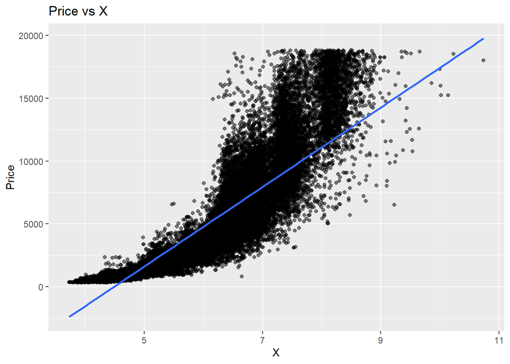

```r
ggplot(diamonds, aes(x, price)) +
  geom_point(alpha=0.5) +
  geom_smooth(method="lm") +
  labs(x="X",
       y="Price",
       title="Price vs X")
```

Let’s take the logarithm of price to check whether there is a linear relationship.

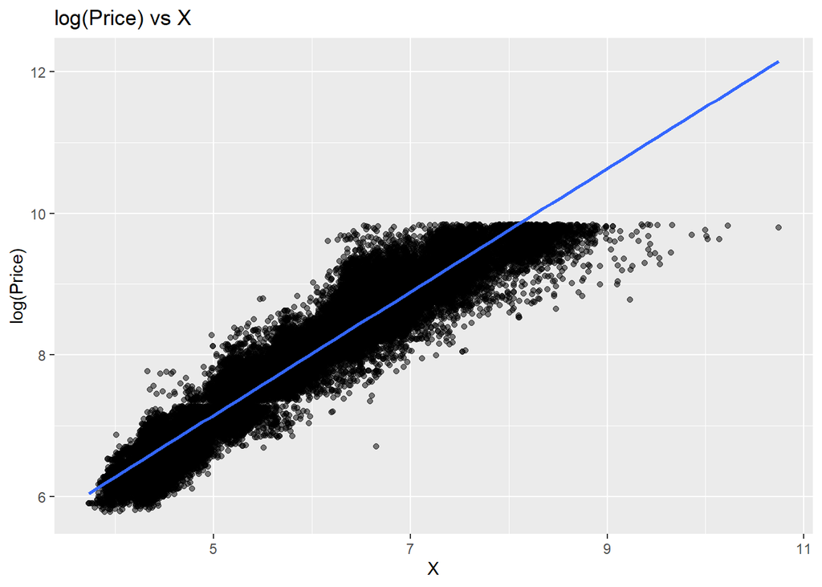

```r
ggplot(diamonds, aes(x, log(price))) +
  geom_point(alpha=0.5) +
  geom_smooth(method="lm") +
  labs(x="X",
       y="log(Price)",
       title="log(Price) vs X")
```

It’s the same for both “y” (width in mm) and “z” (depth in mm), too. So, let’s quickly take the logarithm and re-visualize the graphs.

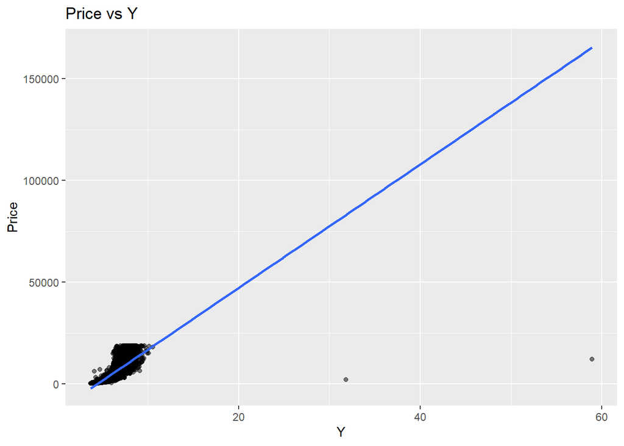

```r
ggplot(diamonds, aes(y, price)) +
  geom_point(alpha=0.5) +
  geom_smooth(method="lm") +
  labs(x="Y",
       y="Price",
       title="Price vs Y")
```

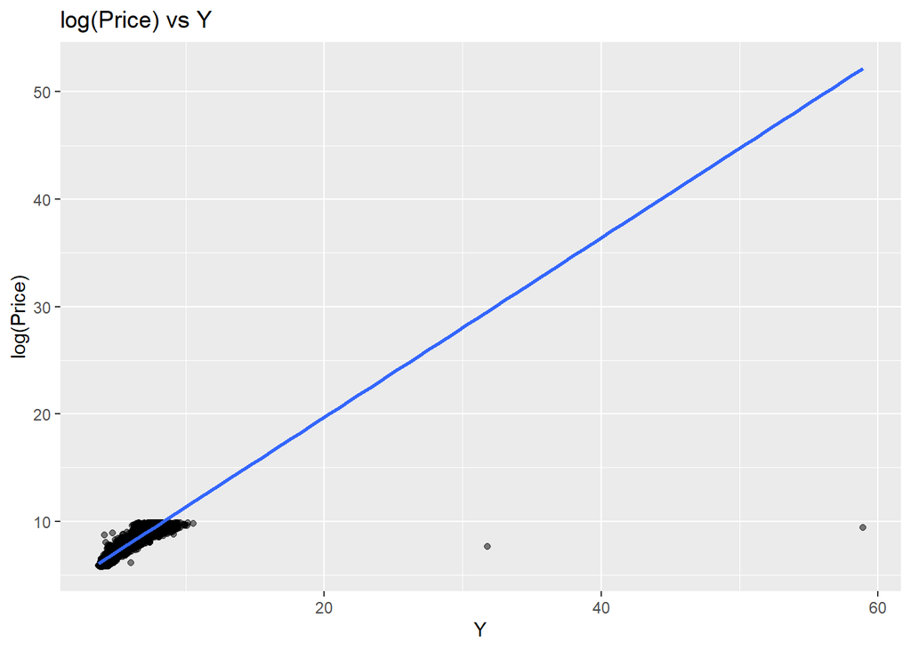

```r
ggplot(diamonds, aes(y, log(price))) +
  geom_point(alpha=0.5) +
  geom_smooth(method="lm") +
  labs(x="Y",
       y="log(Price)",
       title="log(Price) vs Y")
```

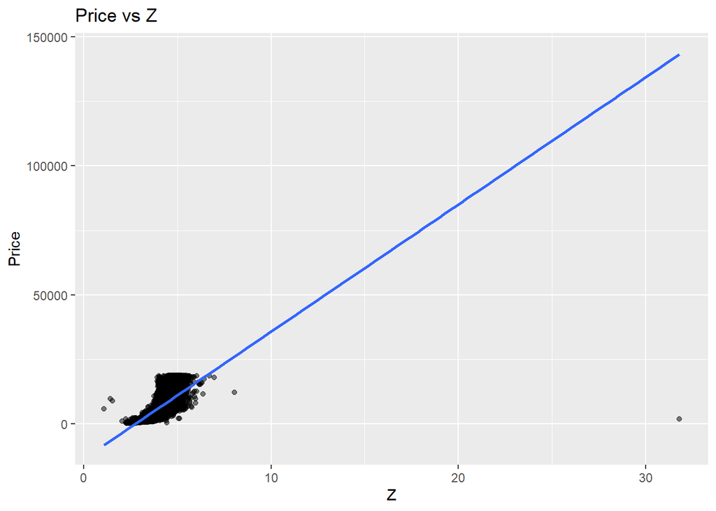

```r
ggplot(diamonds, aes(z, price)) +
  geom_point(alpha=0.5) +
  geom_smooth(method="lm") +
  labs(x="Z",
       y="Price",
       title="Price vs Z")
```

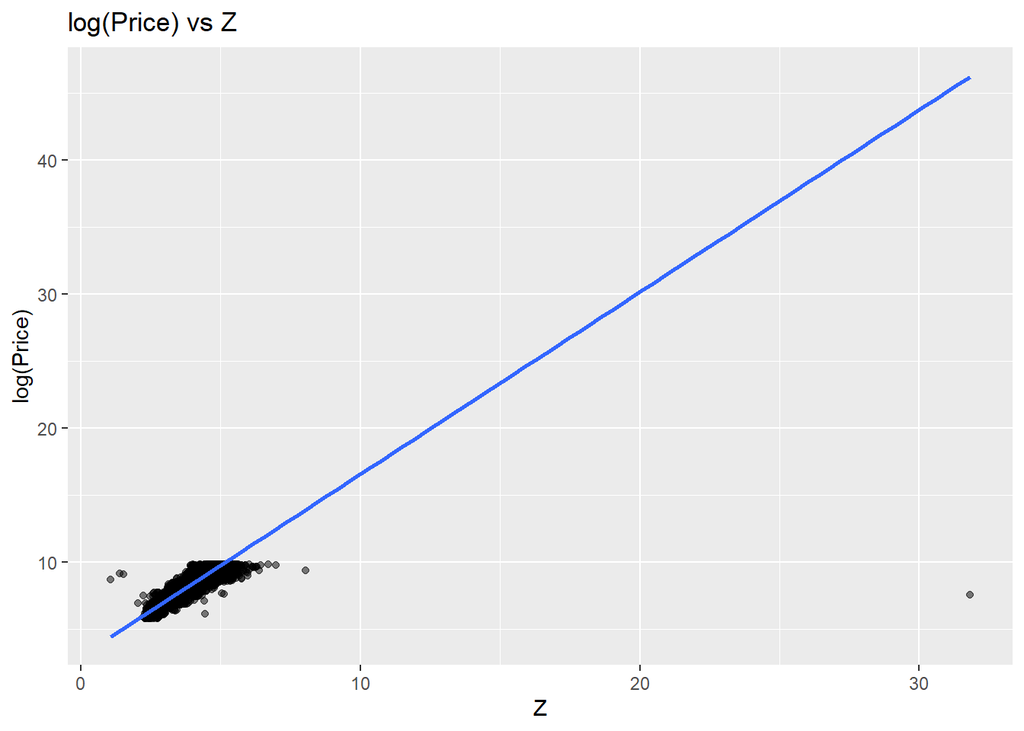

```r
ggplot(diamonds, aes(z, log(price))) +
  geom_point(alpha=0.5) +
  geom_smooth(method="lm") +
  labs(x="Z",
       y="log(Price)",
       title="log(Price) vs Z")
```

So, it’s better to convert price to log(price) for the sake of analysis.

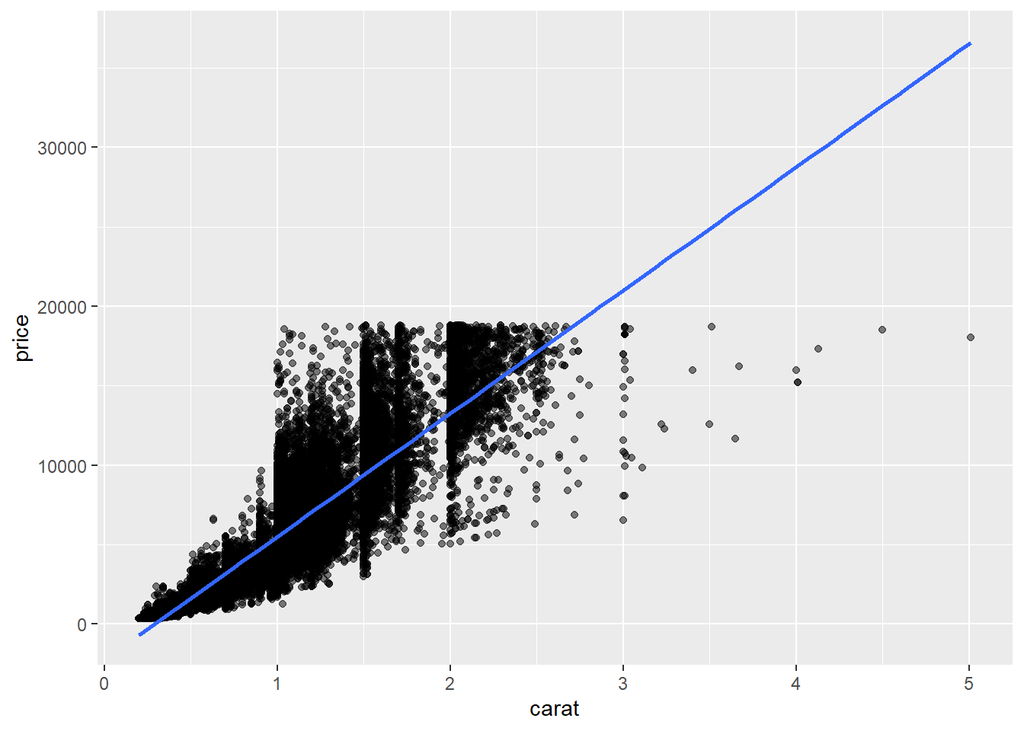

```r
ggplot(diamonds, aes(carat, price)) +
  geom_point(alpha=0.5) +
  geom_smooth(method="lm")
```

```r
  labs(x="Carat",
       y="Price",
       title="Price vs Carat")
```

```
## $x
## [1] "Carat"
##
## $y
## [1] "Price"
##
## $title
## [1] "Price vs Carat"
##
## attr(,"class")
## [1] "labels"
```

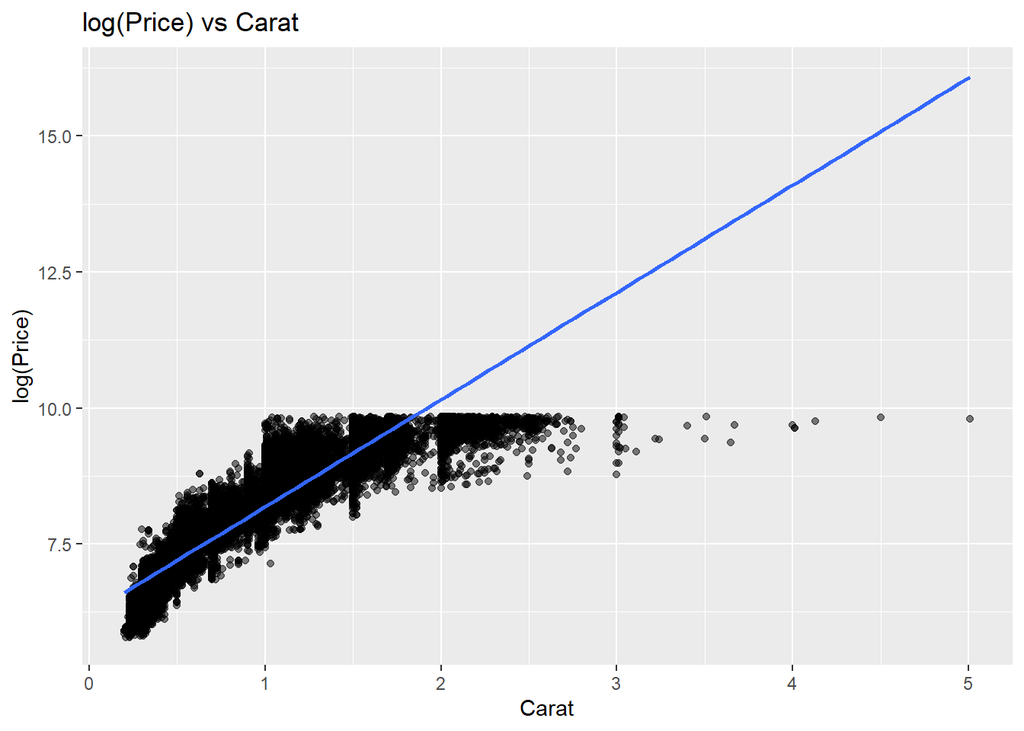

```r
ggplot(diamonds, aes(carat, log(price))) +
  geom_point(alpha=0.5) +
  geom_smooth(method="lm") +
  labs(x="Carat",
       y="log(Price)",
       title="log(Price) vs Carat")
```

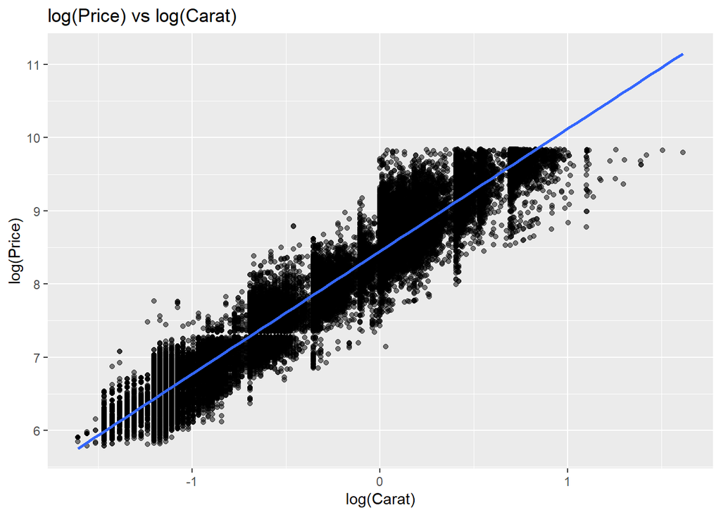

```r
ggplot(diamonds, aes(log(carat), log(price))) +
  geom_point(alpha=0.5) +
  geom_smooth(method="lm") +
  labs(x="log(Carat)",
       y="log(Price)",
       title="log(Price) vs log(Carat)")
```

```r
options(scipen=999)
```

Let’s check the price distribution by color, cut and clarity:

```r
color_diamonds <- diamonds %>%
  group_by(color) %>%
  summarize(avg_col=mean(price))
```

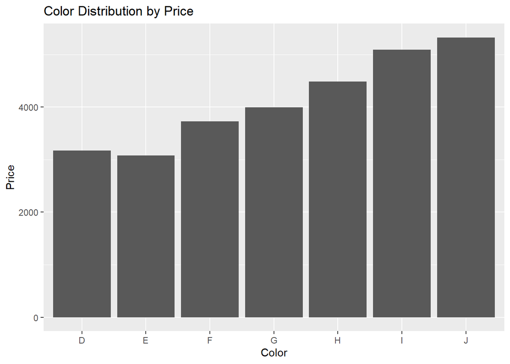

```r
ggplot(color_diamonds, aes(color, avg_col)) +
  geom_col() +
  labs(x="Color",
       y="Price",
       title="Color Distribution by Price")
```

```r
cut_diamonds <- diamonds %>%
  group_by(cut) %>%
  summarize(avg_cut=mean(price))
```

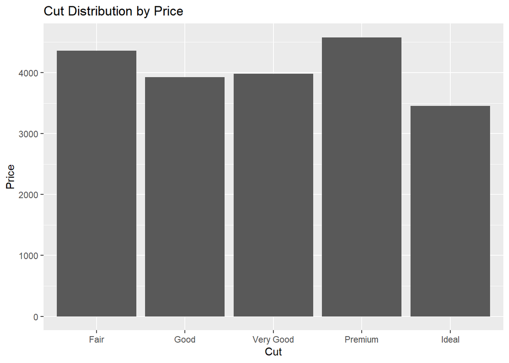

```r
ggplot(cut_diamonds, aes(cut, avg_cut)) +
  geom_col() +
  labs(x="Cut",
       y="Price",
       title="Cut Distribution by Price")
```

```r
clar_diamonds <- diamonds %>%
  group_by(clarity) %>%
  summarize(avg_clar=mean(price))
```

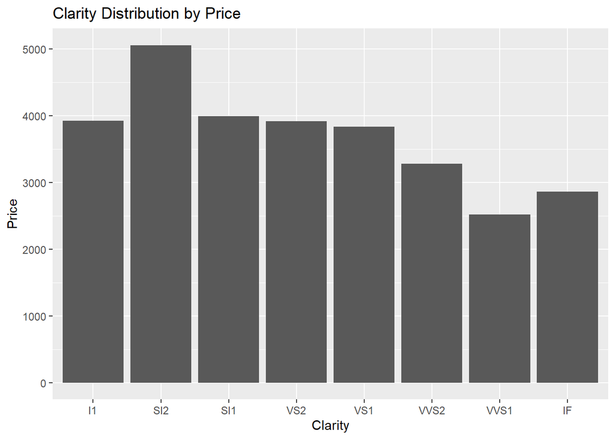

```r
ggplot(clar_diamonds, aes(clarity, avg_clar)) +
  geom_col() +
  labs(x="Clarity",
       y="Price",
       title="Clarity Distribution by Price")
```

Here, you can find the combined version of the distribution above:

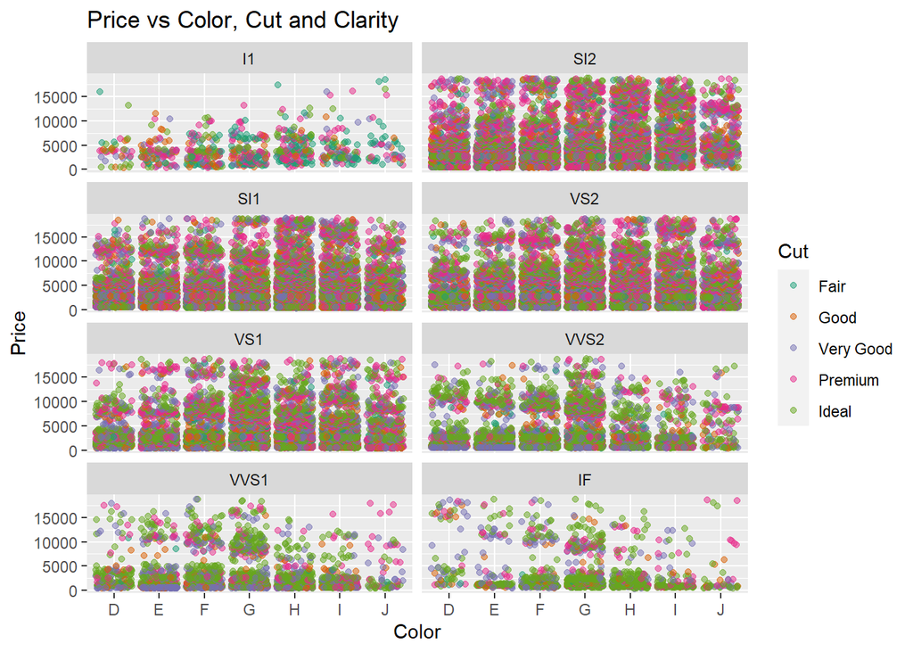

```r
ggplot(diamonds, aes(color, price, color=cut)) +
  geom_jitter(alpha=0.5) +
  facet_wrap(~clarity, ncol=2) +
  labs(x="Color",
       y="Price",
       color="Cut",
       title="Price vs Color, Cut and Clarity") +
  scale_color_brewer(palette="Dark2")
```

From the plot below, we can also infer that x, y, z and price have a positive correlation as all increases simultaneously.

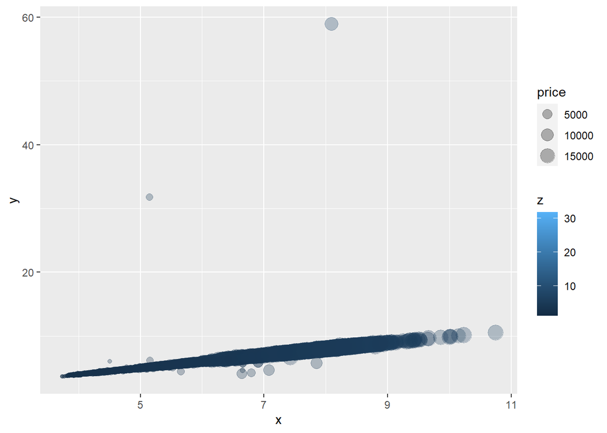

```r
ggplot(diamonds, aes(x, y, color=z, size=price)) + geom_point(alpha=0.3)
```

For the sake of supervised learning, train and test data are split as shown below:

```r
set.seed(503)
diamonds_test <- diamonds %>%
  mutate(diamond_id = row_number()) %>%
  group_by(cut, color, clarity) %>%
  sample_frac(0.2) %>%
  ungroup()

diamonds_train <- anti_join(diamonds %>%
                              mutate(diamond_id = row_number()),diamonds_test, by = "diamond_id")
```

### Classification and Regression Trees (CART)

CART model is constructed as follows:

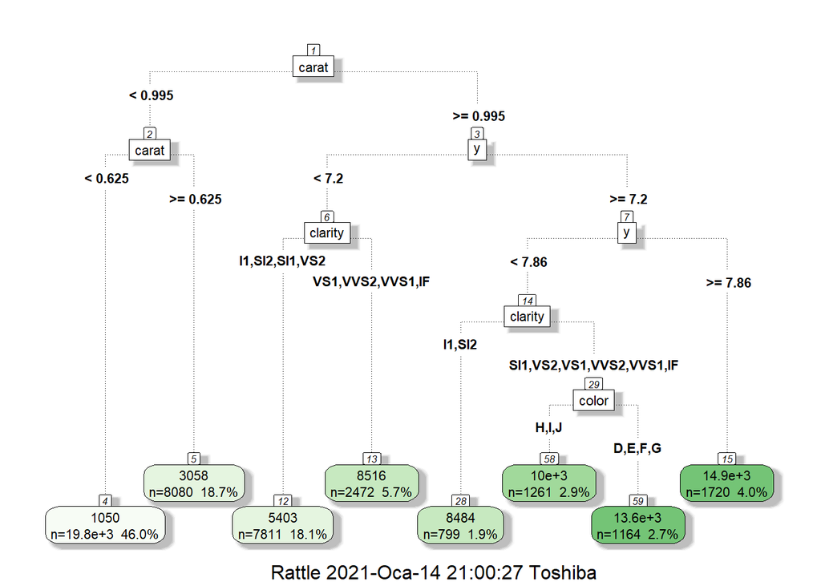

```r
diamonds_model <- rpart(price ~ ., data=diamonds_train[-11])
fancyRpartPlot(diamonds_model, type =5, digits = 3)
```

```r
diamonds_in_sample <- predict(diamonds_model)
```

### Linear Regression

A linear model with the existing values has R squared value of 92% whereas it is 98% when we convert price and carat to log(price) and log(carat).

```r
lm_diamonds1 <- lm(price~carat + cut + clarity + color + x + y + z, data=diamonds_train)
summary(lm_diamonds1)
```

```
##
## Call:
## lm(formula = price ~ carat + cut + clarity + color + x + y +
##     z, data = diamonds_train)
##
## Residuals:
##      Min       1Q   Median       3Q      Max
## -21743.7   -589.9   -182.2    375.9  10800.0
##
## Coefficients:
##             Estimate Std. Error  t value             Pr(>|t|)
## (Intercept)   531.94      93.43    5.693      0.0000000125483 ***
## carat       11437.31      56.54  202.279 < 0.0000000000000002 ***
## cut.L         739.12      22.45   32.925 < 0.0000000000000002 ***
## cut.Q        -336.42      19.64  -17.127 < 0.0000000000000002 ***
## cut.C         183.64      16.97   10.821 < 0.0000000000000002 ***
## cut^4         -15.17      13.60   -1.116               0.2646
## clarity.L    4109.21      33.74  121.779 < 0.0000000000000002 ***
## clarity.Q   -1939.16      31.55  -61.464 < 0.0000000000000002 ***
## clarity.C     982.37      26.98   36.413 < 0.0000000000000002 ***
## clarity^4    -372.00      21.52  -17.283 < 0.0000000000000002 ***
## clarity^5     244.93      17.56   13.950 < 0.0000000000000002 ***
## clarity^6      11.27      15.28    0.737               0.4608
## clarity^7      87.10      13.48    6.461      0.0000000001053 ***
## color.L     -1966.45      19.35 -101.643 < 0.0000000000000002 ***
## color.Q      -686.17      17.59  -39.009 < 0.0000000000000002 ***
## color.C      -162.04      16.40   -9.878 < 0.0000000000000002 ***
## color^4        27.87      15.07    1.850               0.0643 .
## color^5      -101.17      14.23   -7.108      0.0000000000012 ***
## color^6       -58.13      12.94   -4.493      0.0000070546868 ***
## x            -964.57      33.97  -28.398 < 0.0000000000000002 ***
## y              37.79      19.41    1.947               0.0516 .
## z            -287.83      33.96   -8.476 < 0.0000000000000002 ***
## ---
## Signif. codes:  0 '***' 0.001 '**' 0.01 '*' 0.05 '.' 0.1 ' ' 1
##
## Residual standard error: 1126 on 43104 degrees of freedom
## Multiple R-squared:  0.9205, Adjusted R-squared:  0.9205
## F-statistic: 2.377e+04 on 21 and 43104 DF,  p-value: < 0.00000000000000022
```

```r
lm_diamonds2 <- lm(I(log(price))~I(log(carat)) + cut + clarity + color + x + y + z, data=diamonds_train)
summary(lm_diamonds2)
```

```
##
## Call:
## lm(formula = I(log(price)) ~ I(log(carat)) + cut + clarity +
##     color + x + y + z, data = diamonds_train)
##
## Residuals:
##      Min       1Q   Median       3Q      Max
## -1.07021 -0.08534  0.00005  0.08293  1.91805
##
## Coefficients:
##                 Estimate Std. Error  t value             Pr(>|t|)
## (Intercept)    7.8836485  0.0339040  232.529 < 0.0000000000000002 ***
## I(log(carat))  1.7158744  0.0100178  171.282 < 0.0000000000000002 ***
## cut.L          0.1122528  0.0027061   41.482 < 0.0000000000000002 ***
## cut.Q         -0.0313798  0.0023365  -13.430 < 0.0000000000000002 ***
## cut.C          0.0141317  0.0020153    7.012  0.00000000000237803 ***
## cut^4          0.0003575  0.0016148    0.221             0.824809
## clarity.L      0.9146410  0.0040094  228.124 < 0.0000000000000002 ***
## clarity.Q     -0.2463606  0.0037368  -65.928 < 0.0000000000000002 ***
## clarity.C      0.1337691  0.0031973   41.838 < 0.0000000000000002 ***
## clarity^4     -0.0656548  0.0025535  -25.712 < 0.0000000000000002 ***
## clarity^5      0.0269347  0.0020826   12.933 < 0.0000000000000002 ***
## clarity^6     -0.0011425  0.0018127   -0.630             0.528510
## clarity^7      0.0321599  0.0015995   20.106 < 0.0000000000000002 ***
## color.L       -0.4436068  0.0022821 -194.389 < 0.0000000000000002 ***
## color.Q       -0.0986197  0.0020836  -47.331 < 0.0000000000000002 ***
## color.C       -0.0152686  0.0019462   -7.845  0.00000000000000441 ***
## color^4        0.0120571  0.0017879    6.744  0.00000000001561634 ***
## color^5       -0.0031565  0.0016888   -1.869             0.061616 .
## color^6        0.0015729  0.0015351    1.025             0.305544
## x              0.0821100  0.0056181   14.615 < 0.0000000000000002 ***
## y             -0.0023189  0.0023031   -1.007             0.314019
## z              0.0142430  0.0041079    3.467             0.000526 ***
## ---
## Signif. codes:  0 '***' 0.001 '**' 0.01 '*' 0.05 '.' 0.1 ' ' 1
##
## Residual standard error: 0.1336 on 43104 degrees of freedom
## Multiple R-squared:  0.9827, Adjusted R-squared:  0.9827
## F-statistic: 1.166e+05 on 21 and 43104 DF,  p-value: < 0.00000000000000022
```